# Amazon Fine Food Reviews Analysis

The Amazon Fine Food Reviews dataset consists of reviews of fine foods from Amazon.

Number of reviews: 568,454  
Number of users: 256,059  
Number of products: 74,258  
Timespan: Oct 1999 - Oct 2012  
Number of Attributes/Columns in data: 10

Attribute Information:

1. Id
2. ProductId - unique identifier for the product
3. UserId - unqiue identifier for the user
4. ProfileName
5. HelpfulnessNumerator - number of users who found the review helpful
6. HelpfulnessDenominator - number of users who indicated whether they found the review helpful or not
7. Score - rating between 1 and 5
8. Time - timestamp for the review
9. Summary - brief summary of the review
10. Text - text of the review

#### Objective:

Given a review, determine whether the review is positive (Rating of 4 or 5) or negative (rating of 1 or 2).

[Q] How to determine if a review is positive or negative?  
[Ans] We could use the Score/Rating. A rating of 4 or 5 could be cosnidered a positive review. A review of 1 or 2 could be considered negative. A review of 3 is nuetral and ignored. This is an approximate and proxy way of determining the polarity (positivity/negativity) of a review.

## We will analyse only 10k reviews .

```python
%matplotlib inline

import sqlite3
import pandas as pd
import numpy as np
import nltk
import string
import matplotlib.pyplot as plt
import seaborn as sns
from sklearn.feature_extraction.text import TfidfTransformer
from sklearn.feature_extraction.text import TfidfVectorizer

from sklearn.feature_extraction.text import CountVectorizer
from sklearn.metrics import confusion_matrix
from sklearn import metrics
from sklearn.metrics import roc_curve, auc
from nltk.stem.porter import PorterStemmer

# Loading data from sql file
con = sqlite3.connect('database.sqlite')

filtered_data = pd.read_sql_query("""
SELECT *
FROM Reviews
WHERE Score !=3""",con)

filtered_data.shape
```

```
(525814, 10)
```

```python
filtered_data.head(5)
```

|  | Id | ProductId | UserId | ProfileName | HelpfulnessNumerator | HelpfulnessDenominator | Score | Time | Summary | Text |
| --- | --- | --- | --- | --- | --- | --- | --- | --- | --- | --- |
| 0 | 1 | B001E4KFG0 | A3SGXH7AUHU8GW | delmartian | 1 | 1 | 5 | 1303862400 | Good Quality Dog Food | I have bought several of the Vitality canned d... |
| 1 | 2 | B00813GRG4 | A1D87F6ZCVE5NK | dll pa | 0 | 0 | 1 | 1346976000 | Not as Advertised | Product arrived labeled as Jumbo Salted Peanut... |
| 2 | 3 | B000LQOCH0 | ABXLMWJIXXAIN | Natalia Corres "Natalia Corres" | 1 | 1 | 4 | 1219017600 | "Delight" says it all | This is a confection that has been around a fe... |
| 3 | 4 | B000UA0QIQ | A395BORC6FGVXV | Karl | 3 | 3 | 2 | 1307923200 | Cough Medicine | If you are looking for the secret ingredient i... |
| 4 | 5 | B006K2ZZ7K | A1UQRSCLF8GW1T | Michael D. Bigham "M. Wassir" | 0 | 0 | 5 | 1350777600 | Great taffy | Great taffy at a great price. There was a wid... |

```python
# Replacing score > 3 with positive and score < 3 with negative.
filtered_score = filtered_data['Score']
modified_score = filtered_score.map(lambda x:'positive' if x > 3 else 'negative')
filtered_data['Score'] = modified_score
filtered_data.head(5)
```

|  | Id | ProductId | UserId | ProfileName | HelpfulnessNumerator | HelpfulnessDenominator | Score | Time | Summary | Text |
| --- | --- | --- | --- | --- | --- | --- | --- | --- | --- | --- |
| 0 | 1 | B001E4KFG0 | A3SGXH7AUHU8GW | delmartian | 1 | 1 | positive | 1303862400 | Good Quality Dog Food | I have bought several of the Vitality canned d... |
| 1 | 2 | B00813GRG4 | A1D87F6ZCVE5NK | dll pa | 0 | 0 | negative | 1346976000 | Not as Advertised | Product arrived labeled as Jumbo Salted Peanut... |
| 2 | 3 | B000LQOCH0 | ABXLMWJIXXAIN | Natalia Corres "Natalia Corres" | 1 | 1 | positive | 1219017600 | "Delight" says it all | This is a confection that has been around a fe... |
| 3 | 4 | B000UA0QIQ | A395BORC6FGVXV | Karl | 3 | 3 | negative | 1307923200 | Cough Medicine | If you are looking for the secret ingredient i... |
| 4 | 5 | B006K2ZZ7K | A1UQRSCLF8GW1T | Michael D. Bigham "M. Wassir" | 0 | 0 | positive | 1350777600 | Great taffy | Great taffy at a great price. There was a wid... |

# EDA and Deduplication

```python
# In this type of datasets some duplicate reviews are also present which are given by the same username for same product.
# Let's sort this dataset on productid and then remove duplicate reviews.
sorted_data = filtered_data.sort_values('ProductId',axis=0,ascending=True,inplace=False,kind='quicksort',na_position='last')

# Now we will remove duplicate reviews
final_data = sorted_data.drop_duplicates(subset={'UserId','ProfileName','Time','Text'},inplace=False,keep='first')
final_data.shape
```

```
(364173, 10)
```

```python
# Sometime the HelpfulnessNumerator is > HelpfullnessDenominator. We will remove such rows.
final_data = final_data.loc[final_data['HelpfulnessNumerator']<=final_data['HelpfulnessDenominator']]
final_data.shape
```

```
(364171, 10)
```

# Text Preprocessing: Stemming, stop-word removal and Lemmatization.

Now that we have finished deduplication our data requires some preprocessing before we go on further with analysis and making the prediction model.

Hence in the Preprocessing phase we do the following in the order below:-

1. Begin by removing the html tags
2. Remove any punctuations or limited set of special characters like , or . or # etc.
3. Check if the word is made up of english letters and is not alpha-numeric
4. Check to see if the length of the word is greater than 2 (as it was researched that there is no adjective in 2-letters)
5. Convert the word to lowercase
6. Remove Stopwords
7. Finally Snowball Stemming the word (it was obsereved to be better than Porter Stemming)

After which we collect the words used to describe positive and negative reviews

```python
# Function to remove any html tags present in the review
import re
from nltk.corpus import stopwords
from nltk.stem import PorterStemmer

stop_words = list(stopwords.words('english'))
stop = [x.replace('not',' ').replace('nor',' ') for x in stop_words]

# Initializing snowball stemmer
snow_ball_stem = nltk.stem.SnowballStemmer('english')

def clean_html(sent):
    cleaner1 = re.compile('<.*?>')
    cleaned_sent = re.sub(cleaner1,' ',sent)
    return cleaned_sent

def clean_punct(sent):
    cleaner2 = re.compile('[#|,|!|\|/|:|\'|"|;|)|(|?|*|]')
    cleaned_text = re.sub(cleaner2,' ',sent)
    return cleaned_text

print(stop_words)
print('*****************************************')
print(stop)
```

```
['i', 'me', 'my', 'myself', 'we', 'our', 'ours', 'ourselves', 'you', "you're", "you've", "you'll", "you'd", 'your', 'yours', 'yourself', 'yourselves', 'he', 'him', 'his', 'himself', 'she', "she's", 'her', 'hers', 'herself', 'it', "it's", 'its', 'itself', 'they', 'them', 'their', 'theirs', 'themselve…
['i', 'me', 'my', 'myself', 'we', 'our', 'ours', 'ourselves', 'you', "you're", "you've", "you'll", "you'd", 'your', 'yours', 'yourself', 'yourselves', 'he', 'him', 'his', 'himself', 'she', "she's", 'her', 'hers', 'herself', 'it', "it's", 'its', 'itself', 'they', 'them', 'their', 'theirs', 'themselve…
```

```python
# Function to clean the text .
import string
cleaned_data =[]
all_positive_word=[]
all_negative_word=[]
i=0
s=''
str1=''

for sent in final_data['Text'].values:
    sent = clean_html(sent)
    cleaned_sent=[]
    for w in sent.split():
        for word in clean_punct(w).split():
            if((word.isalpha()) and (len(word)>2)):
                if(word.lower() not in stop):
                    s = (snow_ball_stem.stem(word.lower()))
                    cleaned_sent.append(s)
                    if((final_data['Score'].values)[i] == 'positive'):
                        all_positive_word.append(s)
                    if((final_data['Score'].values)[i] == 'negative'):
                        all_negative_word.append(s)
                else:
                    continue
            else:
                continue

    str1 = " ".join(cleaned_sent)
    cleaned_data.append(str1)
    i+=1
print(cleaned_data[100])
```

```
pros dog anyth smell bad mani easi break smaller noth artifici easi con cost dog overal great expens dog anyth sever phobia includ get car walk doorway ignor fear get
```

# We will do analysis for only 10k points.

```python
final_data['Cleaned_Text'] = cleaned_data
data = final_data.sample(10000)
```

# Bag Of Words

```python
from sklearn.feature_extraction.text import CountVectorizer
count_vect = CountVectorizer()
bow_data = count_vect.fit_transform(data['Cleaned_Text'])
bow_data.shape
```

```
(10000, 12511)
```

```python
# Standarizing the data
from sklearn.preprocessing import StandardScaler
standard_bow_data = StandardScaler(with_mean=False).fit_transform(bow_data)

# Converting sparse matrix to dense matrix
from sklearn.decomposition import TruncatedSVD
svd = TruncatedSVD(n_components=100,algorithm='randomized',n_iter=20,random_state=42)
dense_bow_data = svd.fit_transform(standard_bow_data)
```

```python
labels = data['Score'] # This stores the label of all 10k values.

from sklearn.manifold import TSNE
import seaborn as sns
import matplotlib.pyplot as plt
import pandas as pd

model = TSNE(n_components=2,random_state=42,perplexity=10,n_iter=3000)
bow_tsne_data1 = model.fit_transform(dense_bow_data)
bow_tsne_data1.shape
```

```
(10000, 2)
```

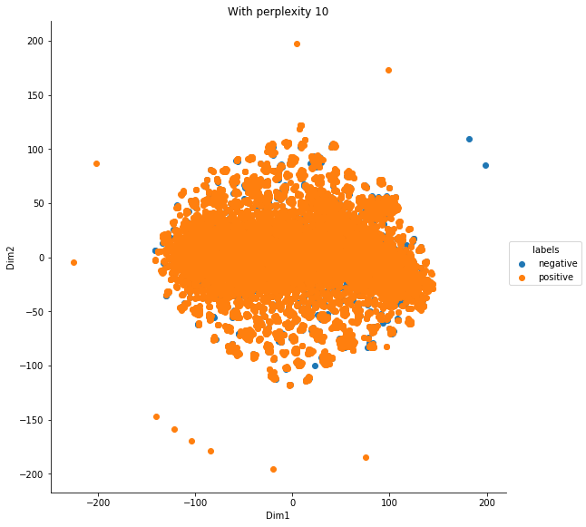

```python
labeled_data = np.vstack((bow_tsne_data1.T,labels)).T

bow_df1 = pd.DataFrame(data=labeled_data,columns=("Dim1","Dim2","labels"))

# Plotting the data
sns.FacetGrid(bow_df1,hue='labels',size=8).map(plt.scatter,"Dim1","Dim2").add_legend()
plt.title("With perplexity 10")
plt.show()
```

```python
#with perplexity 5
model1 = TSNE(n_components=2,random_state=42,perplexity=5,n_iter=3000)
bow_tsne_data2 = model1.fit_transform(dense_bow_data)
```

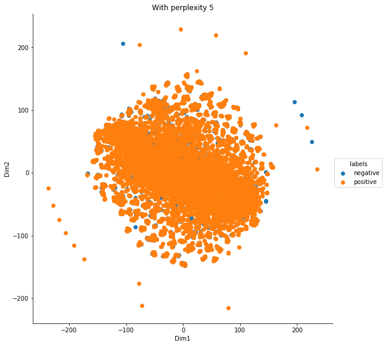

```python
labeled_data1 = np.vstack((bow_tsne_data2.T,labels)).T

bow_df2 = pd.DataFrame(data=labeled_data1,columns=("Dim1","Dim2","labels"))

# Plotting the data
sns.FacetGrid(bow_df2,hue='labels',size=8).map(plt.scatter,"Dim1","Dim2").add_legend()
plt.title("With perplexity 5")
plt.show()
```

```python
#with perplexity 50
model2 = TSNE(n_components=2,random_state=42,perplexity=50,n_iter=3000)
bow_tsne_data3 = model2.fit_transform(dense_bow_data)
```

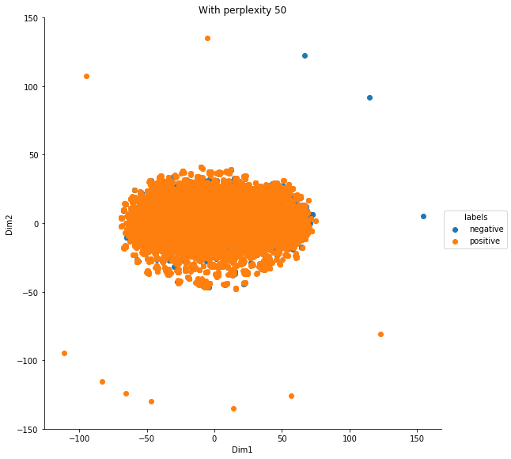

```python
labeled_data2 = np.vstack((bow_tsne_data3.T,labels)).T

bow_df3 = pd.DataFrame(data=labeled_data2,columns=("Dim1","Dim2","labels"))

# Plotting the data
sns.FacetGrid(bow_df3,hue='labels',size=8).map(plt.scatter,"Dim1","Dim2").add_legend()
plt.title("With perplexity 50")
plt.show()
```

# Bi-grams

```python
bigram1 = CountVectorizer(ngram_range=(1,2))
```

```python
bigram_data1 = bigram1.fit_transform(data['Cleaned_Text'])
bigram_data1.shape
```

```
(10000, 212736)
```

```python
# standerizing data
standard_bigram1 = StandardScaler(with_mean=False).fit_transform(bigram_data1)

# Converting sparse matrix to dense matrix
bigram_svd = TruncatedSVD(n_components=200,n_iter=200,algorithm='randomized',random_state=42)
dense_bigram1  = bigram_svd.fit_transform(standard_bigram1)
```

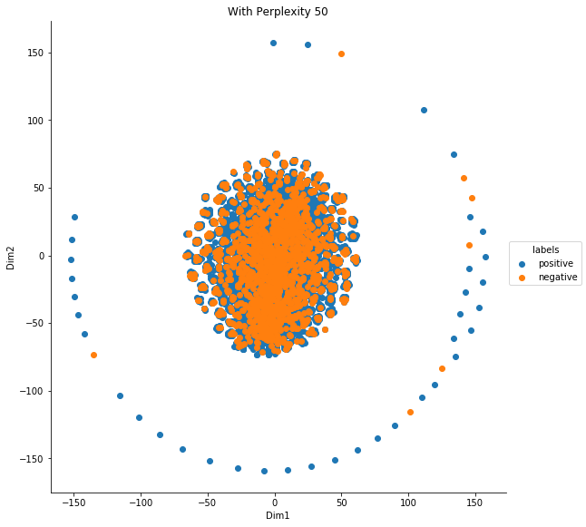

```python
# Plotting tsne with perplexity 50
bigram_tsne_data1 = model2.fit_transform(dense_bigram1)

labeled_bigram1 = np.vstack((bigram_tsne_data1.T,labels)).T

bigram_df1 = pd.DataFrame(data=labeled_bigram1,columns=("Dim1","Dim2","labels"))

sns.FacetGrid(bigram_df1,hue="labels",size=8).map(plt.scatter,"Dim1","Dim2").add_legend()
plt.title("With Perplexity 50")
plt.show()
```

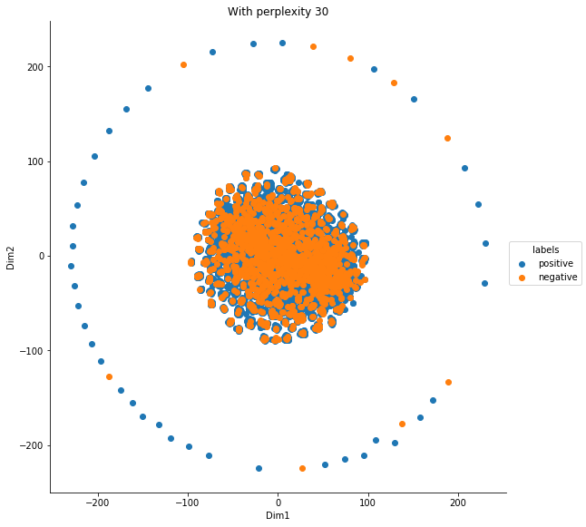

```python
# TSNE With perplexity 30
bigram_tsne_model = TSNE(n_components=2,n_iter=5000,perplexity=30,random_state=42)

bigram_tsne_data2 = bigram_tsne_model.fit_transform(dense_bigram1)

labeled_bigram2 = np.vstack((bigram_tsne_data2.T,labels)).T

bigram_df2 = pd.DataFrame(data=labeled_bigram2,columns=("Dim1","Dim2","labels"))

sns.FacetGrid(bigram_df2,hue='labels',size=8).map(plt.scatter,"Dim1","Dim2").add_legend()
plt.title("With perplexity 30")
plt.show()
```

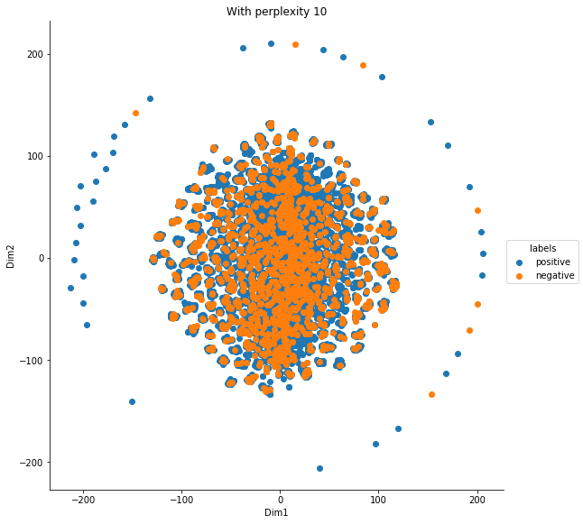

```python
# Tsne with perplexity 10
bigram_tsne_data3 = model.fit_transform(dense_bigram1)

labeled_bigram3 = np.vstack((bigram_tsne_data3.T,labels)).T

bigram_df3 = pd.DataFrame(labeled_bigram3,columns=("Dim1","Dim2","labels"))

sns.FacetGrid(bigram_df3,hue='labels',size=8).map(plt.scatter,'Dim1','Dim2').add_legend()
plt.title("With perplexity 10")
plt.show()
```

# Bigrams and Tri-grams

```python
trigram = CountVectorizer(ngram_range=(1,3))

trigram_data1 = trigram.fit_transform(data['Cleaned_Text'])
trigram_data1.shape
```

```
(10000, 518655)
```

```python
# Standarizing the data
standard_trigram = StandardScaler(with_mean=False).fit_transform(trigram_data1)

# Converting sparse data into dense
dense_trigram = bigram_svd.fit_transform(standard_trigram)
```

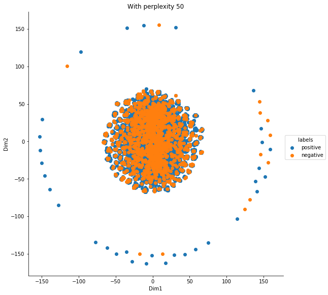

```python
# Tsne with perplexity 50
trigram_tsne_data1 = model2.fit_transform(dense_trigram)

labeled_trigram1 = np.vstack((trigram_tsne_data1.T,labels)).T

trigram_df1 = pd.DataFrame(data=labeled_trigram1,columns=("Dim1","Dim2","labels"))

sns.FacetGrid(trigram_df1,hue='labels',size=8).map(plt.scatter,"Dim1","Dim2").add_legend()
plt.title("With perplexity 50")
plt.show()
```

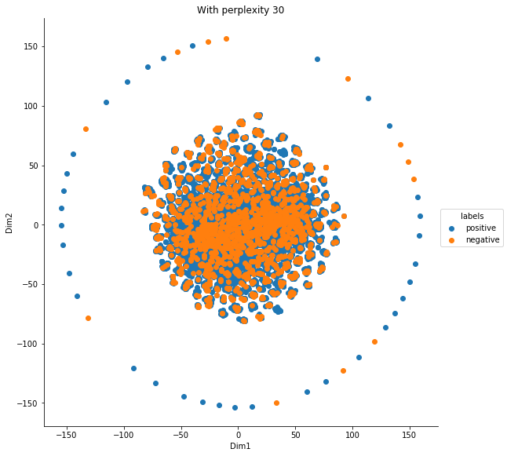

```python
# Tsne with perplexity 30
trigram_tsne_data1 = bigram_tsne_model.fit_transform(dense_trigram)

labeled_trigram2 = np.vstack((trigram_tsne_data1.T,labels)).T

trigram_df2 = pd.DataFrame(data=labeled_trigram2,columns=("Dim1","Dim2","labels"))

sns.FacetGrid(trigram_df2,hue='labels',size=8).map(plt.scatter,"Dim1","Dim2").add_legend()
plt.title("With perplexity 30")
plt.show()
```

# Tf-idf

```python
tfidf1 = TfidfVectorizer(ngram_range=(1,2))
```

```python
tfidf_data = tfidf1.fit_transform(data['Cleaned_Text'])
tfidf_data.shape
```

```
(10000, 217245)
```

```python
feature_names = tfidf1.get_feature_names()

doc = 0
feature_index = tfidf_data[doc,:].nonzero()[1]

for i in feature_index:
    print(feature_names[i],tfidf_data[doc,i])
```

```
big 0.03977818493830226
fan 0.04618096784215786
crystal 0.11825910960793536
light 0.08753332315687684
beverag 0.059299248672358716
like 0.08385418166588027
lemonad 0.13331054319482313
lot 0.035958087810468074
drink 0.06864150557393292
summer 0.05729782164895767
excit 0.051833792625843526
tri 0.024735429116158454
new 0.04069196683361026
margarita 0.14036163148831898
contain 0.03949197104904636
hold 0.050652305444079816
powder 0.046718722982778
packet 0.09811205576036987
make 0.05174097572408446
quart 0.07406819352194781
mix 0.03453822269188741
thorough 0.06966244878663386
result 0.05024426712952593
odd 0.060979009689112074
murki 0.08460108750461398
green 0.04249914823826864
color 0.09664069242707456
almost 0.04005018767134891
could 0.035764995470429224
glow 0.07795557129973611
dark 0.04518827642096567
got 0.036018291796508416
past 0.048485177550367506
weird 0.059827131713318625
pour 0.0504461157064459
bring 0.05017791770712563
mouth 0.050934309694070326
thought 0.04007320677790015
odor 0.06703129835209942
smell 0.040004314601666376
```

[output cut: 112 more lines]

```
cold realli 0.09124660370949184
realli disappoint 0.08460108750461398
disappoint like 0.09124660370949184
like margarita 0.08735922593170352
margarita cocktail 0.09124660370949184
cocktail hope 0.09124660370949184
would make 0.06276789381962325
make lowcal 0.09124660370949184
lowcal altern 0.09124660370949184
altern tradit 0.08460108750461398
tradit guess 0.09124660370949184
guess stick 0.08735922593170352
stick origin 0.08735922593170352
origin crystal 0.08735922593170352
light lemonad 0.08460108750461398
```

```python
# Standarizing data
standard_tfidf_data1 = StandardScaler(with_mean=False).fit_transform(tfidf_data)

# coneverting sparse matrix into dense matrix
svd = TruncatedSVD(n_components=100,n_iter=100,algorithm='randomized',random_state=42)
dense_tfidf_data=svd.fit_transform(standard_tfidf_data1)
dense_tfidf_data.shape
```

```
(10000, 100)
```

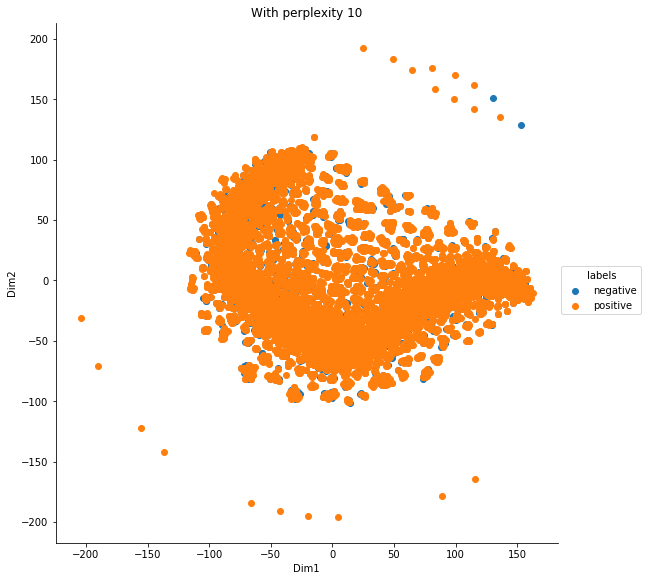

```python
# Reducing 100 dimension to 2 dimension using tsne model
tfidf_tsne_data1 = model.fit_transform(dense_tfidf_data)
tfidf_tsne_data1.shape

tfidf_labeled_data1 = np.vstack((tfidf_tsne_data1.T,labels)).T

tfidf_df1 = pd.DataFrame(data=tfidf_labeled_data1,columns=('Dim1','Dim2','labels'))

sns.FacetGrid(tfidf_df1,hue='labels',size=8).map(plt.scatter,'Dim1','Dim2').add_legend()
plt.title("With perplexity 10")
plt.show()
```

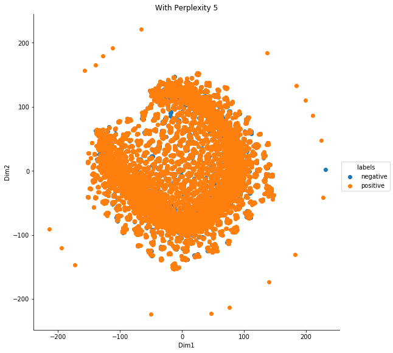

```python
# Using model of tsne with perplexity 5
tfidf_tsne_data2 = model1.fit_transform(dense_tfidf_data)

labeled_tfidf_data2 = np.vstack((tfidf_tsne_data2.T,labels)).T

tfidf_df2 = pd.DataFrame(data=labeled_tfidf_data2,columns=("Dim1","Dim2","labels"))

sns.FacetGrid(tfidf_df2,hue='labels',size=8).map(plt.scatter,'Dim1','Dim2').add_legend()
plt.title("With Perplexity 5")
plt.show()
```

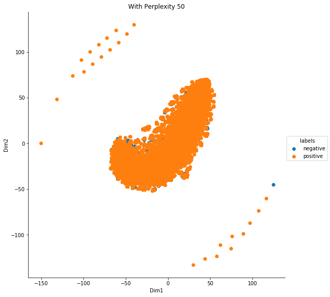

```python
# Tsne with perplexity 50
tfidf_tsne_data3 = model2.fit_transform(dense_tfidf_data)

tfidf_labeled_data3 = np.vstack((tfidf_tsne_data3.T,labels)).T

tfidf_df3 = pd.DataFrame(data=tfidf_labeled_data3,columns=("Dim1","Dim2","labels"))

sns.FacetGrid(tfidf_df3,hue='labels',size=8).map(plt.scatter,"Dim1","Dim2").add_legend()
plt.title("With Perplexity 50")
plt.show()
```